# Data processing

In this file, we build several dataframes that are used in the manuscript.qmd file. The following figure summarizes how these dataframes are built.

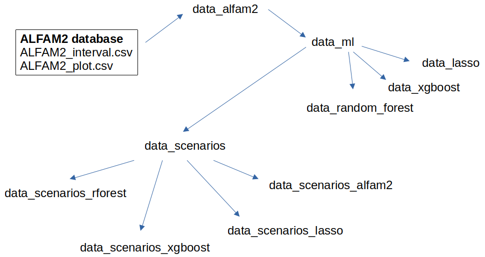

From the files of the ALFAM2 database (available in a Zenodo repository at https://zenodo.org/records/8109634), we first construct data_alfam2, which corresponds to the dataset used in Hafner et al (2019). From data_alfam2, we construct data_ml by retaining only the last observation of each PMID. The dynamics of climatic variables are preserved through class variables. From data_ml, we create data_lasso, data_xgboost, and data_random_forest, all of which contain the same information but are formatted according to the packages used to build the respective models. Additionally, from data_ml, we generate data_scenarios, which correspond to various scenarios on which we test the models. These scenarios are based on quantiles derived from data_ml. From data_scenarios we create four dataframes containing the same information but formatted according to the packages used for the different models.

```r
library ("ggplot2")
library ("dplyr")
library ("tidyr")
```

# data_alfam2

Construction of the data_alfam2 dataframe.

```r
# these two files come from the ALFAM2 Zenodo repository (https://zenodo.org/records/8109634)
data_interval_level = read.csv (file = "../data/Hafner_et_al_2019/ALFAM2_interval.csv")
data_plot_level = read.csv (file = "../data/Hafner_et_al_2019/ALFAM2_plot.csv")

# these two files come from the supplementary material of Hafner et al (2019)
calibration_subset_pmids = read.csv (file = "../data/Hafner_et_al_2019/1-s2.0-S1352231018308069-mmc1.csv")
evaluation_subset_pmids = read.csv (file = "../data/Hafner_et_al_2019/1-s2.0-S1352231018308069-mmc2.csv")

pmids = rbind (evaluation_subset_pmids %>% mutate (dataset = "Evaluation subset"),
               calibration_subset_pmids %>% mutate (dataset = "Calibration subset"))
```

```r
data_alfam2 = data_interval_level %>%

    filter (pmid %in% pmids$pmid) %>%
    left_join (pmids, by = "pmid") %>%

    filter (ct <= 78) %>%
    select (j.NH3, e.cum, e.rel, pmid, ct, dt, air.temp, wind.2m, rain.rate, rain.cum, dataset)  %>%

    # adding plot level informations --------
    left_join (

        data_plot_level %>%
            filter (pmid %in% pmids$pmid) %>%
            select (pmid, country, tan.app, app.method, app.rate, man.dm, man.ph, man.source, incorp, time.incorp) %>%
            rename (app.mthd = app.method, t.incorp = time.incorp),

        by = "pmid"

    ) %>%
    # --------

    replace_na (list (rain.rate = 0)) %>%
    replace_na (list (rain.cum = 0)) %>%

    mutate (wind.2m = replace_na (wind.2m, mean (wind.2m, na.rm = TRUE)), .by = pmid) %>%
    mutate (air.temp = replace_na (air.temp, mean (air.temp, na.rm = TRUE)), .by = pmid) %>%

    rename (time = ct)

save (data_alfam2, file = "processed_data/data_alfam2.Rdata")
```

```r
df_join = data_alfam2 %>% select (pmid, country) %>% distinct
```

```r
data_alfam2 %>%
  summarise (n_obs = n(), n_trial = length (unique (pmid)))
```

```
  n_obs n_trial
1  5939     538
```

# data_ml

Construction of the dama_ml dataframe.

```r
data_ml = data_alfam2 %>%

    mutate_if (is.character, as.factor) %>%

    mutate (t.incorp = ifelse (t.incorp <= 0.25, 0, t.incorp)) %>%

    mutate (t.incorp = ifelse (t.incorp == 0 & incorp == "none", 1000, t.incorp)) %>%
    mutate (t.incorp = replace_na (t.incorp, 1000)) %>%

    mutate (man.ph = replace_na (man.ph, median (man.ph, na.rm = TRUE)), .by = man.source) %>%

    # we round dt and time in order to compute the new climatic variables
    # cf the next chunk
    mutate (dt = round (dt, digits = 2)) %>%
    mutate (time = cumsum (dt), .by = pmid) %>%

    {.}
```

```r
# data = data_ml
# pmids = data %>% pull (pmid) %>% unique
#
# data_ml = NULL
#
# for (i in pmids) {
#
#     data_tmp = data %>% filter (pmid == i)
#
#     time_max = max (data_tmp$time)
#
#     time = seq (0, (time_max - 0.01), by = 0.01)
#
#     group = c(
#         sapply (c (1 : 5), function (j) rep (j, 400)) %>% as.vector,
#         rep (6, (length (time) - 2000))
#     )
#
#     # here we added 1+e-8 for numerical reasons, ('19.8 - 16.7 <= 3.1' return FALSE)
#     temp = sapply (time, function (j) data_tmp %>% filter ((time - dt) <= j + 1e-8 & j + 1e-8 < time) %>% pull (air.temp))
#     wind = sapply (time, function (j) data_tmp %>% filter ((time - dt) <= j + 1e-8 & j + 1e-8 < time) %>% pull (wind.2m))
#     rain = sapply (time, function (j) data_tmp %>% filter ((time - dt) <= j + 1e-8 & j + 1e-8 < time) %>% pull (rain.rate))
#
#
#     df_temp = data.frame (time = time, temp = temp, group = group) %>%
#
#         summarise (temp = mean (temp), .by = group) %>%
#         pivot_wider (names_from = group, values_from = temp, names_prefix = "temp_")
#
#
#     df_wind = data.frame (time = time, wind = wind, group = group) %>%
#
#         summarise (wind = mean (wind), .by = group) %>%
#         pivot_wider (names_from = group, values_from = wind, names_prefix = "wind_")
#
#
#     df_rain = data.frame (time = time, rain = rain, group = group) %>%
#
#         summarise (rain = mean (rain), .by = group) %>%
#         pivot_wider (names_from = group, values_from = rain, names_prefix = "rain_")
#
#
#     data_tmp = cbind (
#         data_tmp[nrow (data_tmp), ] %>% select (dataset, e.cum, e.rel, pmid, country, time, tan.app, app.mthd, app.rate, man.dm, man.ph, man.source, incorp, t.incorp),
#         df_temp,
#         df_wind,
#         df_rain
#     )
#
#     data_ml = rbind (data_ml, data_tmp)
#
# }

# save (data_ml, file = "processed_data/data_ml.Rdata")

load (file = "processed_data/data_ml.Rdata")
```

```r
dim (data_ml)
```

```
[1] 538  32
```

## data_random_forest

Construction of the data_random_forest dataframe.

```r
data_random_forest = data_ml %>%

    mutate (man.source = as.numeric (recode (man.source, "pig" = 1, "cat" = 0))) %>%
    mutate (app.mthd = as.numeric (recode (app.mthd, "bc" = 1, "ts" = 2, "os" = 3, "bsth" = 4))) %>%
    mutate (incorp = as.numeric (recode (incorp, "none" = 1, "shallow" = 2, "deep" = 3)))

save (data_random_forest, file = "processed_data/data_random_forest.Rdata")
```

## data_xgboost

Construction of the data_xgboost dataframe.

```r
data_xgboost = data_ml %>%

    mutate (man.source = as.numeric (recode (man.source, "pig" = 1, "cat" = 0))) %>%
    mutate (app.mthd = as.numeric (recode (app.mthd, "bc" = 1, "ts" = 2, "os" = 3, "bsth" = 4))) %>%
    mutate (incorp = as.numeric (recode (incorp, "none" = 1, "shallow" = 2, "deep" = 3)))

save (data_xgboost, file = "processed_data/data_xgboost.Rdata")
```

## data_lasso

Construction of the data_lasso dataframe.

```r
data_lasso = data_ml %>%

    # making the dummy variables --------
    mutate (man.source.pig = ifelse (man.source == "pig", 1, 0)) %>%
    select (- man.source) %>%

    mutate (app.mthd.bc = ifelse (app.mthd == "bc", 1, 0)) %>%
    mutate (app.mthd.ts = ifelse (app.mthd == "ts", 1, 0)) %>%
    mutate (app.mthd.os = ifelse (app.mthd == "os", 1, 0)) %>%
    select (- app.mthd) %>%

    mutate (incorp.shallow = ifelse (incorp == "shallow", 1, 0)) %>%
    mutate (incorp.deep = ifelse (incorp == "deep", 1, 0)) %>%
    select (- incorp) %>%
    # ---------

    mutate (e.cum = log (e.cum)) %>%

    {.}

save (data_lasso, file = "processed_data/data_lasso.Rdata")
```

# data_scenarios

Construction of the data_scenarios dataframe.

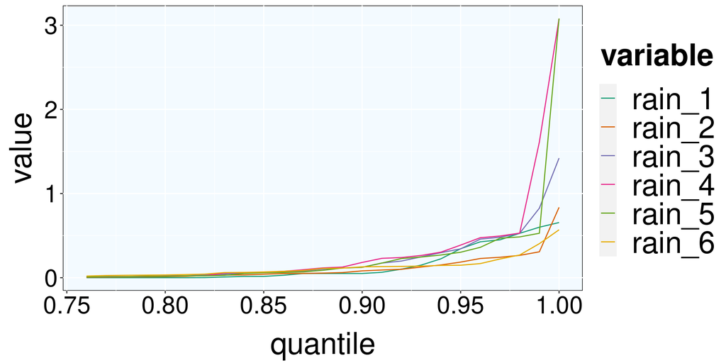

```r
data_ml %>%

    select (rain_1, rain_2, rain_3, rain_4, rain_5, rain_6) %>%

    apply (2, quantile, probs = seq (0.01, 1, by = 0.01)) %>%
    as.data.frame %>%
    mutate (quantile = row_number () / 100) %>%
    pivot_longer (cols = - c (quantile), names_to = "variable") %>%

    filter (quantile > 0.75) %>%
    ggplot () +
        geom_line (aes (x = quantile, y = value, color = variable)) +
        scale_color_manual (values = Dark2)
```

```r
quartiles_climatic_variable = cbind (

    data_ml %>%

    select (temp_1, temp_2, temp_3, temp_4, temp_5, temp_6,
            wind_1, wind_2, wind_3, wind_4, wind_5, wind_6) %>%

    apply (2, quantile, probs = c (0.25, 0.75)) %>%
    as.data.frame,

    data_ml %>%

    select (rain_1, rain_2, rain_3, rain_4, rain_5, rain_6) %>%

    apply (2, quantile, probs = c (0.25, 0.95)) %>%
    as.data.frame
)
```

```r
quartiles_climatic_variable %>% round (digits = 1)
```

```
    temp_1 temp_2 temp_3 temp_4 temp_5 temp_6 wind_1 wind_2 wind_3 wind_4
25%   11.2   10.8    8.7    8.0    8.1    9.2    2.3    2.3    1.8    1.4
75%   18.2   18.5   16.2   14.2   14.0   16.0    5.0    4.6    3.8    3.7
    wind_5 wind_6 rain_1 rain_2 rain_3 rain_4 rain_5 rain_6
25%    1.4    2.2    0.0    0.0    0.0    0.0    0.0    0.0
75%    3.7    4.1    0.3    0.2    0.3    0.4    0.3    0.1
```

```r
grid_climatic_variable = quartiles_climatic_variable [, c(1 : 6)] %>%
    cross_join (quartiles_climatic_variable [, c(7 : 12)]) %>%
    cross_join (quartiles_climatic_variable [, c(13 : 18)]) %>%

    mutate (group_temp = ifelse (temp_1 == quartiles_climatic_variable[1, 1], "q1", "q2")) %>%
    mutate (group_wind = ifelse (wind_1 == quartiles_climatic_variable[1, 7], "q1", "q2")) %>%
    mutate (group_rain = ifelse (rain_2 == quartiles_climatic_variable[1, 13], "q1", "q2"))
```

```r
quartiles_plot_level_variable = data_ml %>%

    select (tan.app, app.rate, man.dm) %>%

    apply (2, quantile, probs = c (0.25, 0.75)) %>%
    as.data.frame
```

```r
quartiles_plot_level_variable %>% round (digits = 1)
```

```
    tan.app app.rate man.dm
25%    36.7     18.7    3.8
75%    80.3     36.7    8.2
```

```r
grid_plot_level_variable = expand_grid (
    time = 72,
    tan.app = quartiles_plot_level_variable$tan.app,
    app.rate = quartiles_plot_level_variable$app.rate,
    man.dm = quartiles_plot_level_variable$man.dm,
    man.ph = 7.5,
    man.source = c ("pig", "cat"),
    incorp = c("none", "shallow"),
    app.mthd = c ("bc", "bsth", "os", "ts"),
    t.incorp = c (0, 1000)

) %>%

    filter (! (incorp == "none" & t.incorp %in% c(0))) %>%
    filter (! (incorp == "shallow" & t.incorp == 1000)) %>%
    filter (! (app.mthd %in% c ("bsth", "os", "ts") & incorp == "shallow"))
```

```r
nrow (grid_plot_level_variable)
```

```
[1] 80
```

```r
# in the following calcul, the terms in parenthesis correspond to the variables time, tan.app, app.rate, man.dm, man.ph and man.source
# the last terms correspond to the variables incorp, app.mthd, and t.incorp

# incorp = none
(1 * 2 * 2 * 2 * 1 * 2) * 1 * 4 * 1 +

# incorp = shallow
(1 * 2 * 2 * 2 * 1 * 2) * 1 * 1 * 1
```

```
[1] 80
```

```r
data_scenarios = cross_join (grid_climatic_variable, grid_plot_level_variable) %>%

    mutate (pmid = row_number ()) %>%

    # reordering the variables
    select (pmid, time, tan.app, app.mthd, app.rate, man.dm, man.ph, man.source, incorp, t.incorp,
            temp_1, temp_2, temp_3, temp_4, temp_5, temp_6,
            wind_1, wind_2, wind_3, wind_4, wind_5, wind_6,
            rain_1, rain_2, rain_3, rain_4, rain_5, rain_6,
            group_temp, group_wind, group_rain)

save (data_scenarios, file = "processed_data/data_scenarios.Rdata")
```

## data_scenarios_random_forest

Construction of the data_scenarios_random_forest dataframe.

```r
data_scenarios_random_forest = data_scenarios %>%
    select (- pmid, - group_temp, - group_wind, - group_rain) %>%

    mutate (man.source = as.numeric (recode (man.source, "pig" = 1, "cat" = 0))) %>%
    mutate (app.mthd = as.numeric (recode (app.mthd, "bc" = 1, "ts" = 2, "os" = 3, "bsth" = 4))) %>%
    mutate (incorp = as.numeric (recode (incorp, "none" = 1, "shallow" = 2))) %>%

    {.}

save (data_scenarios_random_forest, file = "processed_data/data_scenarios_random_forest.Rdata")
```

## data_scenarios_xgboost

Construction of the data_scenarios_xgboost dataframe.

```r
data_scenarios_xgboost = data_scenarios %>%

    select (- pmid, - group_temp, - group_wind, - group_rain) %>%

    mutate (man.source = as.numeric (recode (man.source, "pig" = 1, "cat" = 0))) %>%
    mutate (app.mthd = as.numeric (recode (app.mthd, "bc" = 1, "ts" = 2, "os" = 3, "bsth" = 4))) %>%
    mutate (incorp = as.numeric (recode (incorp, "none" = 1, "shallow" = 2))) %>%

    {.}

save (data_scenarios_xgboost, file = "processed_data/data_scenarios_xgboost.Rdata")
```

## data_scenarios_lasso

Construction of the data_scenarios_lasso dataframe.

```r
data_scenarios_lasso = data_scenarios %>%

    select (- pmid, - group_temp, - group_wind, - group_rain) %>%

    # making the dummy variables --------
    mutate (man.source.pig = ifelse (man.source == "pig", 1, 0)) %>%
    select (- man.source) %>%

    mutate (app.mthd.bc = ifelse (app.mthd == "bc", 1, 0)) %>%
    mutate (app.mthd.ts = ifelse (app.mthd == "ts", 1, 0)) %>%
    mutate (app.mthd.os = ifelse (app.mthd == "os", 1, 0)) %>%
    select (- app.mthd) %>%

    mutate (incorp.shallow = ifelse (incorp == "shallow", 1, 0)) %>%
    mutate (incorp.deep = 0) %>%
    select (- incorp)
    # ---------

save (data_scenarios_lasso, file = "processed_data/data_scenarios_lasso.Rdata")
```

## data_scenarios_alfam2

Construction of the data_scenarios_alfam2 dataframe.

```r
data_scenarios_alfam2 = data_scenarios %>%

    mutate (t.incorp = na_if (t.incorp, 1000)) %>%

    select (- time) %>%

    pivot_longer (cols = contains ("temp_") | contains ("wind_") | contains ("rain_"), names_to = c (".value", "time"), names_pattern = "(.+)_(.+)") %>%

    select (- group_temp, - group_wind, - group_rain) %>%

    rename (air.temp = temp, wind.2m = wind, rain.rate = rain) %>%

    mutate (time = as.numeric (recode (time, "1" = "4", "2" = "8", "3" = "12", "4" = "16", "5" = "20", "6" = "72"))) %>%
    mutate (dt = ifelse (time == 72, (72 - 20), 4), .after = time) %>%

    mutate (rain.cum = cumsum (rain.rate), .by = pmid)

save (data_scenarios_alfam2, file = "processed_data/data_scenarios_alfam2.Rdata")
```